# Statistics with R

Hypothesis Testing

Zhuanghua Shi (Strongway), Fredrik Allenmark

11 June 2019

# Hypothesis testing

Today we mainly cover

1. t-distribution and t-tests
   - Simple t-test
   - Paired t-test
2. Analysis of Variance (ANOVA)
   - one-way ANOVA
   - repeated-measures ANOVA
   - multiple factor ANOVA

# Null hypothesis testing

- A common practice in statistics is testing whether a “null” hypothesis can be rejected
- The null hypothesis can for example be that there is no difference between two groups
- Or that some experimenental manipulation does not affect performance
- The idea is that in general we do not know how big an effect, if any, to expect of an experimental manipulation
- But we are interested in knowing whether there is any effect at all
- That is, we want to know whether the null hypothesis can be rejected

# Sampling distributions and p-values

- Typically null hypothesis testing works like this:
- Some aspects of a data set are summarized in terms of a test statitic (e.g. t, F, chi-squared…)
- A probability distribution for this test statistic, given the null hypothesis, is known (under certain assumptions)

# Sampling distributions and p-values

- If our test statistic falls far out on the tail of the distribution our data are unlikely given the null hypothesis
- We can calculate just how unlikely by integrating over the tail “outside” of the test statistic
- This gives us a p-value

# Sampling distributions and p-values

- For example this shows the boundaries a t-statistic would need to fall outside for a p-value < 0.05 for a t-test with 19 degrees of freedom

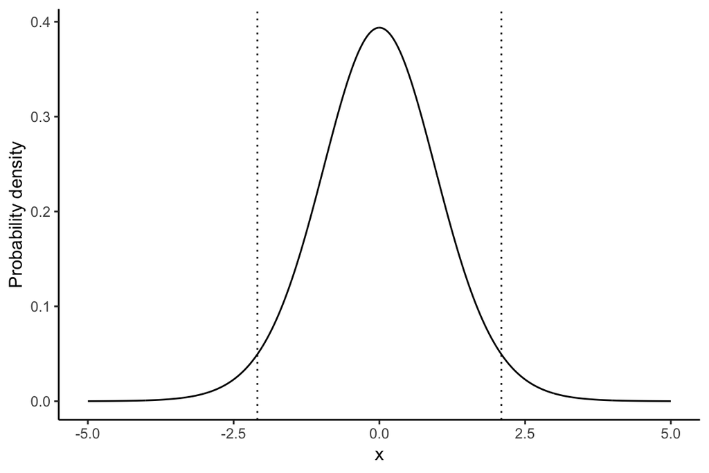

```r
xp <- seq(-5, 5,0.01)
data.frame(x = xp, y = dt(xp,19)) %>%
  ggplot(aes(x=x, y=y)) + geom_line() + theme_classic() +
  labs(y="Probability density") + geom_vline(xintercept = qt(0.025, 19), linetype = 3) +
  geom_vline(xintercept = qt(0.975, 19), linetype = 3)
```

# Sampling distributions and p-values

- The p-value says how likely it is to get data as extreme or more extreme than ours given the null hypothesis
- That is, if the experiment was repeated many times how often would we get data more extreme than this if the null hypothesis is true

# Type I and Type II errors

- Type I error: Null hypothesis is rejected despite being true
- Type I error rate ($\alpha$): significance level
  - $\alpha$ determines how small a p-value needs to be for the null hypothesis to be rejected
  - A convention is to use $\alpha$ = 0.05
- Type II error: Null hypothesis is not rejected despite being false
  - Type II error rate ($\beta$): 1 - statistical power
  - The power is a function of effect size
  - Small effect sizes require larger sample sizes to get the same power
  - Software like G*Power can be used for calculating the sample size required to get a particular level of power

# Confidence intervals

- A confidence interval is a way of indicating the uncertainty about a parameter
- Confidence intervals can be calculated for different confidence levelse, 95% is a common choice
- A 95% confidence interval means that if the experiment was repeated many times the confidence interval would contain the true value of the parameter on 95% of those repetitions

# t-distribution

Suppose we got $n$ samples ($X_i$) from a unknown population $N(\mu, \sigma^2)$, and we are interested in comparison the mean $\bar X$ to $\mu$. Often we replace $\sigma$ with the estimated standard deviation $S$, then $(\bar X - \mu)/(S/\sqrt n)$ is a t-distribution with $n-1$ degrees of freedom.

- t-distribution is bell shaped with thicker tails than the normal distribution
- `t.test()` is the command in R for the statistical test based on the t-distribution
- The distribution itself can be accessed through the R-functions
  - dt() for the probability density function
  - pt() for the cumulative distribution function

# t-distribution

- with larger degrees of freedom the t-distribution becomes increasingly similar to a normal distribution

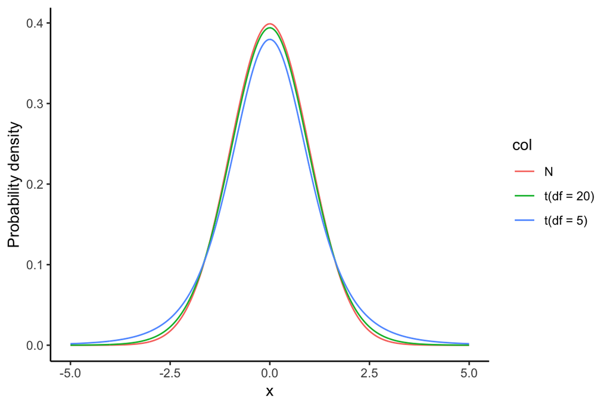

```r
xp <- seq(-5, 5,0.01)
data.frame(x = rep(xp, 3), col = c(rep("t(df = 5)", length(xp)), rep("t(df = 20)", length(xp)),
                                   rep("N", length(xp))), y = c(dt(xp,5), dt(xp,20),
                                                                dnorm(xp))) %>%
  ggplot(aes(x=x, y=y, color=col)) + geom_line() + theme_classic() +
  labs(y="Probability density")
```

# t-distribution

- with larger degrees of freedom the t-distribution becomes increasingly similar to a normal distribution

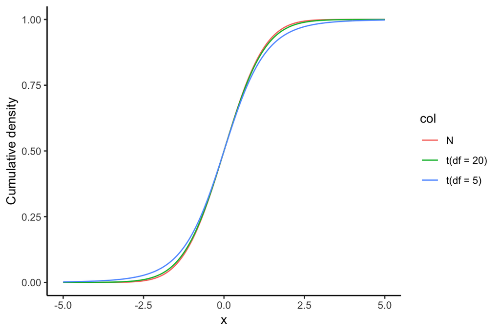

```r
xp <- seq(-5, 5,0.01)
data.frame(x = rep(xp, 3), col = c(rep("t(df = 5)", length(xp)), rep("t(df = 20)", length(xp)),
                                   rep("N", length(xp))), y = c(pt(xp,5), pt(xp,20),
                                                                pnorm(xp))) %>%
  ggplot(aes(x=x, y=y, color=col)) + geom_line() + theme_classic() +
  labs(y="Cumulative density")
```

# R formulas

R formulas are used in various modeling and statistics packages. They specify the dependences between variables in the model.

- A typical formula: y is a function of x, a, and b

> y ~ x + a + b
- The sepal width is a function of petal width, conditioned on species

> Sepal.Width ~ Petal.Width | Species

# R formulas

Symbols used in formulas

- `+` for adding independent variables
- `-` for removing terms
- `:` for interaction
- `*` for crossing
- `%in%` for nesting
- ‘0’ can be used to specify a line through the origin (rarely useful in practice)

```r
y ~ x1*x2 # same as y ~ x1 + x2 + x1:x2

y ~ x1*x2 - x2 # ignore x2, i.e. same as y ~ x1 + x1:x2

y ~ x1 %in% x2 # same as x2:x1

y ~ 0 + x1 # line through the origin
```

# Example: a simple t-test

- `sleep` data from R datasets:
  - the effect of two soporific drugs (increase in hours of sleep compared to control) on 10 patients

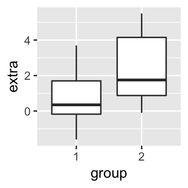

```r
ggplot(sleep, aes(x=group,
    y = extra)) +
  geom_boxplot()
```

# Example: a simple t-test

- A simple non-paired test using a formula

```r
stat_t = t.test(extra ~ group, data = sleep)
stat_t
```

```
##
##  Welch Two Sample t-test
##
## data:  extra by group
## t = -1.8608, df = 17.776, p-value = 0.07939
## alternative hypothesis: true difference in means is not equal to 0
## 95 percent confidence interval:
##  -3.3654832  0.2054832
## sample estimates:
## mean in group 1 mean in group 2
##            0.75            2.33
```

# Example: a simple t-test

- A simple non-paired test using separate data vectors

```r
group1_extra <- filter(sleep, group==1)$extra
group2_extra <- filter(sleep, group==2)$extra
stat_t = t.test(group1_extra, group2_extra)
stat_t
```

```
##
##  Welch Two Sample t-test
##
## data:  group1_extra and group2_extra
## t = -1.8608, df = 17.776, p-value = 0.07939
## alternative hypothesis: true difference in means is not equal to 0
## 95 percent confidence interval:
##  -3.3654832  0.2054832
## sample estimates:
## mean of x mean of y
##      0.75      2.33
```

# Example: a paired t-test

- For a paired t-test you simply need to add the parameter “paired = TRUE”

```r
stat_t = t.test(extra ~ group, data = sleep, paired = TRUE)
stat_t
```

```
##
##  Paired t-test
##
## data:  extra by group
## t = -4.0621, df = 9, p-value = 0.002833
## alternative hypothesis: true difference in means is not equal to 0
## 95 percent confidence interval:
##  -2.4598858 -0.7001142
## sample estimates:
## mean of the differences
##                   -1.58
```

# Example: a paired t-test - “manual” calculation

- Paired t-test statistic: $t=\frac{mean(X1-X2)}{sd(X1-X2)/\sqrt{N}}$

```r
group1_extra <- filter(sleep, group==1)$extra
group2_extra <- filter(sleep, group==2)$extra
diff <- group1_extra - group2_extra
N <- length(diff)
t_value <-  mean(diff)/(sd(diff)/sqrt(N))
t_value
```

```
## [1] -4.062128
```

```r
pt(t_value, N-1)*2
```

```
## [1] 0.00283289
```

# Example: a paired t-test

- Our p-value corresponds to the area under the curve outside the two dotted lines (at 4.06 and -4.06)

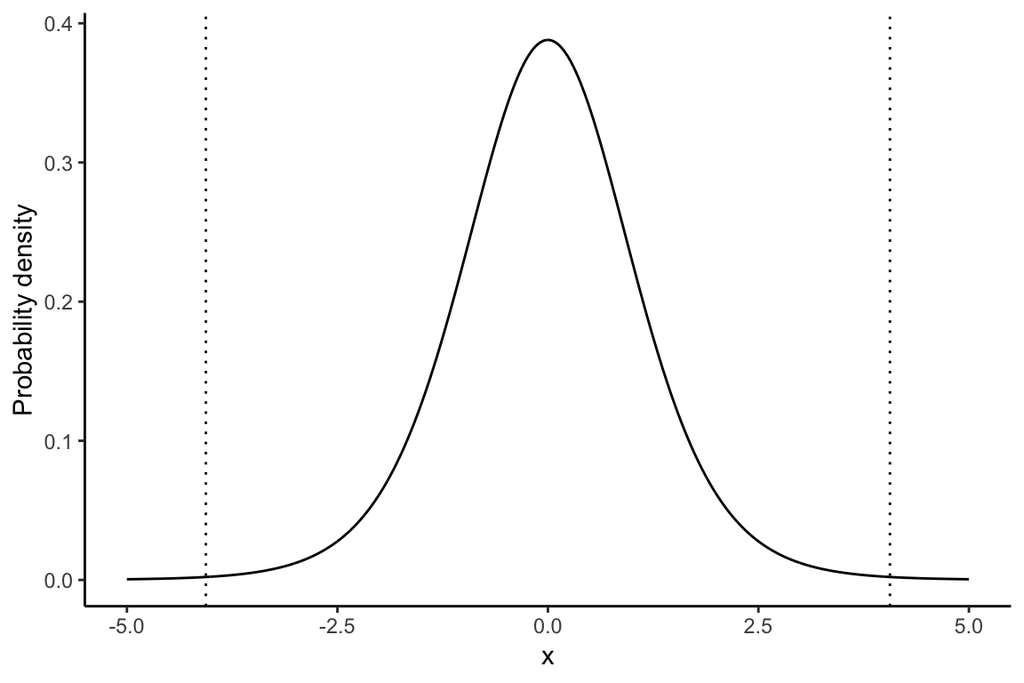

```r
data.frame(x = xp, y = dt(xp,N-1)) %>%
  ggplot(aes(x=x, y=y)) + geom_line() + theme_classic() +
  labs(y="Probability density") + geom_vline(xintercept = t_value, linetype = 3) +
  geom_vline(xintercept = - t_value, linetype = 3)
```

# ANOVA Test

You need to use Analysis of Variance (ANOVA) when

- You have more than 2 groups (categorical variable)

and/or

- More than 2 measures from the same subjects (repeated measures ANOVA)

and

- A single *continuous* dependent variable

Null Hypothesis:

- All groups are equal

Alternative Hypothesis:

- At least one group is different from the others

# Variance partitioning in ANOVA

- Total variance can be divided into:
- Variability that can be attributed to differences between groups
  - We call this explained variance or between-group variability
  - $\sum{_{i=1}^{K} n_i (\bar{y_i} - \bar{y})^2 / (K-1)}$
- Variability attributed to all other factors - within group variability
  - We call this unexplained variance or within-group variability
  - $\sum{_{i=1}^{K} \sum{_{j=1}^{n_i} (y_{ij} - \bar{y_i})^2 / (N-K)}}$

# F-test

- The ratio between the between and within group variance is the basis for the F-statistic
- F = (Explained variance)/(Unexplained variance)
- F = (Between-group variability)/(Within-group variability)
- The F statistic follows the F-distribution with degrees of freedom:
  - d1 = number of groups - 1
  - d2 = sample size - number of groups
- The F statistic is written as F(d1,d2)
  - e.g. for 20 samples in 2 groups: F(1, 18)
- The F-statistic is used in the F-test, which is used (among other things) in ANOVA
- The F-distribution is available in R with the functions df and pf

# Example: A simple ANOVA

- command `aov()`

```r
sleep %>% aov(extra ~ group, data = .) %>%
  tidy()
```

```
## # A tibble: 2 x 6
##   term         df sumsq meansq statistic p.value
##   <chr>     <dbl> <dbl>  <dbl>     <dbl>   <dbl>
## 1 group         1  12.5  12.5       3.46  0.0792
## 2 Residuals    18  64.9   3.60     NA    NA
```

# Example: A simple ANOVA - “manual” calculation (1)

- Explained variance: $\sum{_{i=1}^{K} n_i (\bar{y_i} - \bar{y}) / (K-1)}$

```r
EV <- sum((c(mean(group1_extra), mean(group2_extra)) - mean(sleep$extra))^2)*10
EV
```

```
## [1] 12.482
```

- Unexplained variance: $\sum{_{i=1}^{K} \sum{_{j=1}^{n_i} (y_{ij} - \bar{y_i}) / (N-K)}}$

```r
UV_g1 <- sum((group1_extra - mean(group1_extra))^2)
UV_g2 <- sum((group2_extra - mean(group2_extra))^2)
UV <- (UV_g1 + UV_g2)/18
UV
```

```
## [1] 3.604778
```

# Example: A simple ANOVA - “manual” calculation (2)

- F-statistic: (Explained variance)/(Unexplained variance)

```r
F <- EV/UV
F
```

```
## [1] 3.462627
```

- p-value: pf(1,18)

```r
pf(F, 1, 18, lower.tail = FALSE)
```

```
## [1] 0.07918671
```

# Example: Repeated measures ANOVA

```r
sleep %>% aov(extra ~ group + Error(ID/group), data = .) -> aov1
summary(aov1)
```

```
##
## Error: ID
##           Df Sum Sq Mean Sq F value Pr(>F)
## Residuals  9  58.08   6.453
##
## Error: ID:group
##           Df Sum Sq Mean Sq F value  Pr(>F)
## group      1 12.482  12.482    16.5 0.00283 **
## Residuals  9  6.808   0.756
## ---
## Signif. codes:  0 '***' 0.001 '**' 0.01 '*' 0.05 '.' 0.1 ' ' 1
```

# Conditions for ANOVA

- Independence
- Approximate normality: distribution of the response variable should be nearly normal within each group
- Equal variance: groups should have roughly equal variability
- Sphericity: equal variance of pairswise differences between within-subjects conditions
  - Only relevant when a within-subject factor has 3 or more levels
  - When sphericity is violated corrections can be made by altering the degrees of freedom

# ezANOVA

- `ez` package by Michael Lawrence facilitates easy analysis of factorial experiments.
- It also contains simulated data from the Attention Network Test (ANT)

```r
library(ez)
data(ANT)
ANT %>% dplyr::filter(error == 0) %>%
  group_by(group, cue, flank) %>%
  summarise(mRT = mean(rt)) -> mRTs
head(mRTs,3)
```

```
## # A tibble: 3 x 4
## # Groups:   group, cue [1]
##   group   cue   flank         mRT
##   <fct>   <fct> <fct>       <dbl>
## 1 Control None  Neutral      428.
## 2 Control None  Congruent    429.
## 3 Control None  Incongruent  499.
```

# ezANOVA and ANT

- Visualize the data

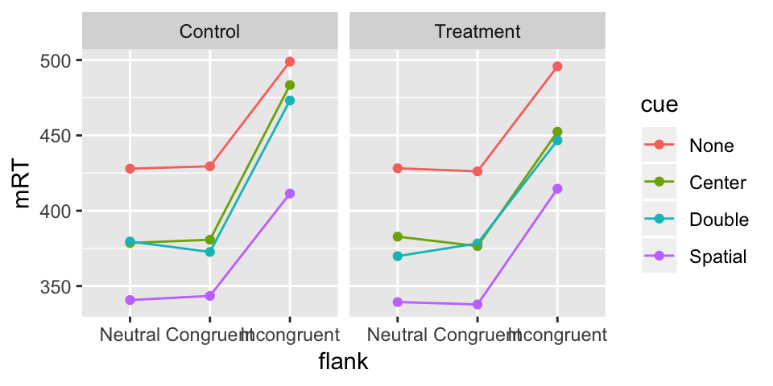

```r
mRTs %>% ggplot(aes(flank, mRT, color = cue, group = cue)) +
  geom_point() + geom_line() + facet_wrap(~group)
```

# ezANOVA and parameters

- ezANOVA parameters
  - data - data.frame table
  - dv - dependent variable
  - wid - subject id
  - within - within factors, multiple using .() list
  - between - between factors
  - between_covariates - covariates
- Return
  - Mauchly’s test for specifity
  - Sphericity corrections
  - Levene’s test for Homogeneity
  - AOV

# Test on ANT data

```r
results <- ezANOVA(filter(ANT, error == 0),
                   rt, subnum, within=.(cue,flank),
                   between = group)
knitr::kable(results$ANOVA)
```

|  | Effect | DFn | DFd | F | p | p<.05 | ges |
| --- | --- | --- | --- | --- | --- | --- | --- |
| 2 | group | 1 | 18 | 18.430592 | 0.0004378 | * | 0.0763336 |
| 3 | cue | 3 | 54 | 516.605213 | 0.0000000 | * | 0.8966229 |
| 5 | flank | 2 | 36 | 1350.598810 | 0.0000000 | * | 0.9271058 |
| 4 | group:cue | 3 | 54 | 2.553236 | 0.0649749 |  | 0.0411044 |
| 6 | group:flank | 2 | 36 | 8.768499 | 0.0007901 | * | 0.0762743 |
| 7 | cue:flank | 6 | 108 | 5.193357 | 0.0000994 | * | 0.1143670 |
| 8 | group:cue:flank | 6 | 108 | 6.377225 | 0.0000090 | * | 0.1368696 |

# Test on ANT data - test for sphericity

- ezANOVA automatically also tests for violations of sphericity

```r
knitr::kable(results$`Mauchly's Test for Sphericity`)
```

|  | Effect | W | p | p<.05 |
| --- | --- | --- | --- | --- |
| 3 | cue | 0.7828347 | 0.5366835 |  |
| 4 | group:cue | 0.7828347 | 0.5366835 |  |
| 5 | flank | 0.8812738 | 0.3415406 |  |
| 6 | group:flank | 0.8812738 | 0.3415406 |  |
| 7 | cue:flank | 0.1737053 | 0.1254796 |  |
| 8 | group:cue:flank | 0.1737053 | 0.1254796 |  |

# Test on ANT data - sphericity corrections

- ezANOVA provides two different types of sphericity corrections:
  - GG = Greenhouse-Geisser
  - HF = Huynh-Feldt
- The “GGe” and “HFe” indicates how much to alter the degrees of freedom
  - corrected df = GGe (or HFe) * uncorrected df

```r
knitr::kable(results$`Sphericity Corrections`)
```

|  | Effect | GGe | p[GG] | p[GG]<.05 | HFe | p[HF] | p[HF]<.05 |
| --- | --- | --- | --- | --- | --- | --- | --- |
| 3 | cue | 0.8652559 | 0.0000000 | * | 1.0239520 | 0.0000000 | * |
| 4 | group:cue | 0.8652559 | 0.0747205 |  | 1.0239520 | 0.0649749 |  |
| 5 | flank | 0.8938738 | 0.0000000 | * | 0.9858964 | 0.0000000 | * |
| 6 | group:flank | 0.8938738 | 0.0012978 | * | 0.9858964 | 0.0008438 | * |
| 7 | cue:flank | 0.6022111 | 0.0015462 | * | 0.7721473 | 0.0004746 | * |
| 8 | group:cue:flank | 0.6022111 | 0.0003424 | * | 0.7721473 | 0.0000717 | * |

# Practice session

Now we apply those tests for the *search data*.